# Support Vector Machines (SVM)

# Introduction

The objective of the support vector machine algorithm is to find a hyperplane in an N-dimensional space(N — the number of features) that distinctly classifies the data points.

# Hyperplanes and Support Vectors

In-class

# Linearly separable vs non-linearly separable

In-class

# Illustration

- Maximized margins

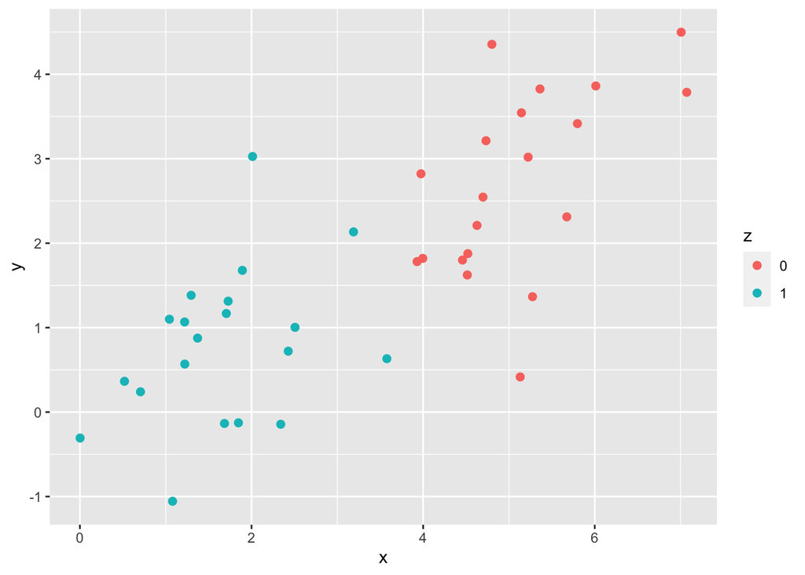

- There are many possible hyperplanes that could be chosen to classify data points.
- Our objective is to find a plane that has the maximum margin.
- Support vectors: data points that are closer to the hyperplane and influence the position and orientation of the hyperplane.

# R code

```r
library(palmerpenguins)
data(penguins)
```

Splitting data into training and test set

```r
library(tidymodels)
set.seed(123)
penguins <- na.omit(penguins)
penguins_split <- initial_split(penguins, strata = species)
penguins_train <- training(penguins_split)
summary(penguins_train)
```

```
##       species          island    bill_length_mm bill_depth_mm
##  Adelie   :109   Biscoe   :119   Min.   :33.1   Min.   :13.10
##  Chinstrap: 51   Dream    : 95   1st Qu.:39.2   1st Qu.:15.70
##  Gentoo   : 89   Torgersen: 35   Median :44.1   Median :17.30
##                                  Mean   :44.0   Mean   :17.22
##                                  3rd Qu.:48.5   3rd Qu.:18.70
##                                  Max.   :59.6   Max.   :21.50
##  flipper_length_mm  body_mass_g       sex           year
##  Min.   :172.0     Min.   :2700   female:116   Min.   :2007
##  1st Qu.:190.0     1st Qu.:3600   male  :133   1st Qu.:2007
##  Median :197.0     Median :4050                Median :2008
##  Mean   :201.2     Mean   :4245                Mean   :2008
##  3rd Qu.:214.0     3rd Qu.:4850                3rd Qu.:2009
##  Max.   :231.0     Max.   :6300                Max.   :2009
```

```r
penguins_test <- testing(penguins_split)
summary(penguins_test)
```

```
##       species         island   bill_length_mm  bill_depth_mm
##  Adelie   :37   Biscoe   :44   Min.   :32.10   Min.   :13.60
##  Chinstrap:17   Dream    :28   1st Qu.:39.50   1st Qu.:15.47
##  Gentoo   :30   Torgersen:12   Median :45.20   Median :17.25
##                                Mean   :43.99   Mean   :17.01
##                                3rd Qu.:48.70   3rd Qu.:18.50
##                                Max.   :58.00   Max.   :21.10
##  flipper_length_mm  body_mass_g       sex          year
##  Min.   :180.0     Min.   :2850   female:49   Min.   :2007
##  1st Qu.:189.0     1st Qu.:3550   male  :35   1st Qu.:2008
##  Median :196.0     Median :3925               Median :2008
##  Mean   :200.2     Mean   :4094               Mean   :2008
##  3rd Qu.:210.5     3rd Qu.:4631               3rd Qu.:2009
##  Max.   :230.0     Max.   :5850               Max.   :2009
```

Next, let’s create cross-validation resamples of the training data, to evaluate our models.

```r
set.seed(234)
penguins_folds <- vfold_cv(penguins_train, strata = species)
penguins_folds
```

```
## #  10-fold cross-validation using stratification
## # A tibble: 10 × 2
##    splits           id
##    <list>           <chr>
##  1 <split [223/26]> Fold01
##  2 <split [224/25]> Fold02
##  3 <split [224/25]> Fold03
##  4 <split [224/25]> Fold04
##  5 <split [224/25]> Fold05
##  6 <split [224/25]> Fold06
##  7 <split [224/25]> Fold07
##  8 <split [224/25]> Fold08
##  9 <split [224/25]> Fold09
## 10 <split [226/23]> Fold10
```

Next, let’s preprocess our data to get it ready for modeling.

```r
penguins_rec <- recipe(species ~ island + bill_length_mm + bill_depth_mm + flipper_length_mm + body_mass_g + sex, data = penguins_train)

penguins_rec2 <- recipe(species ~ island + bill_length_mm + bill_depth_mm + flipper_length_mm + body_mass_g + sex, data = penguins_train)  %>%
   step_normalize(body_mass_g)

penguins_prep <- prep(penguins_rec)
penguins_prep
```

```
## Recipe
##
## Inputs:
##
##       role #variables
##    outcome          1
##  predictor          6
##
## Training data contained 249 data points and no missing data.
```

```r
juice(penguins_prep)
```

```
## # A tibble: 249 × 7
##    island    bill_length_mm bill_depth_mm flipper_length_mm body_mass_g sex
##    <fct>              <dbl>         <dbl>             <int>       <int> <fct>
##  1 Torgersen           40.3          18                 195        3250 female
##  2 Torgersen           36.7          19.3               193        3450 female
##  3 Torgersen           38.9          17.8               181        3625 female
##  4 Torgersen           39.2          19.6               195        4675 male
##  5 Torgersen           41.1          17.6               182        3200 female
##  6 Torgersen           38.6          21.2               191        3800 male
##  7 Torgersen           34.6          21.1               198        4400 male
##  8 Torgersen           38.7          19                 195        3450 female
##  9 Torgersen           42.5          20.7               197        4500 male
## 10 Torgersen           34.4          18.4               184        3325 female
## # … with 239 more rows, and 1 more variable: species <fct>
```

## Random forest

```r
rf_spec <- rand_forest(trees = 1000) %>%
  set_engine("ranger") %>%
  set_mode("classification")

rf_spec
```

```
## Random Forest Model Specification (classification)
##
## Main Arguments:
##   trees = 1000
##
## Computational engine: ranger
```

## SVM

```r
svm_spec <- svm_rbf(cost = 0.5) %>%
  set_engine("kernlab") %>%
  set_mode("classification")

svm_spec
```

```
## Radial Basis Function Support Vector Machine Specification (classification)
##
## Main Arguments:
##   cost = 0.5
##
## Computational engine: kernlab
```

```r
penguins_wf <- workflow() %>%
  add_recipe(penguins_rec)

penguins_wf
```

```
## ══ Workflow ════════════════════════════════════════════════════════════════════
## Preprocessor: Recipe
## Model: None
##
## ── Preprocessor ────────────────────────────────────────────────────────────────
## 0 Recipe Steps
```

```r
## Illustration only

penguins_prep2 <- prep(penguins_rec2)
penguins_prep2
```

```
## Recipe
##
## Inputs:
##
##       role #variables
##    outcome          1
##  predictor          6
##
## Training data contained 249 data points and no missing data.
##
## Operations:
##
## Centering and scaling for body_mass_g [trained]
```

```r
juice(penguins_prep2)
```

```
## # A tibble: 249 × 7
##    island    bill_length_mm bill_depth_mm flipper_length_mm body_mass_g sex
##    <fct>              <dbl>         <dbl>             <int>       <dbl> <fct>
##  1 Torgersen           40.3          18                 195      -1.21  female
##  2 Torgersen           36.7          19.3               193      -0.963 female
##  3 Torgersen           38.9          17.8               181      -0.751 female
##  4 Torgersen           39.2          19.6               195       0.520 male
##  5 Torgersen           41.1          17.6               182      -1.27  female
##  6 Torgersen           38.6          21.2               191      -0.539 male
##  7 Torgersen           34.6          21.1               198       0.187 male
##  8 Torgersen           38.7          19                 195      -0.963 female
##  9 Torgersen           42.5          20.7               197       0.309 male
## 10 Torgersen           34.4          18.4               184      -1.11  female
## # … with 239 more rows, and 1 more variable: species <fct>
```

```r
penguins_wf2 <- workflow() %>%
  add_recipe(penguins_rec2)
penguins_wf2
```

```
## ══ Workflow ════════════════════════════════════════════════════════════════════
## Preprocessor: Recipe
## Model: None
##
## ── Preprocessor ────────────────────────────────────────────────────────────────
## 1 Recipe Step
##
## • step_normalize()
```

Now we can add a model, and the fit to each of the resamples. First, we can fit the random forest model.

```r
set.seed(1234)
rf_rs <- penguins_wf %>%
  add_model(rf_spec) %>%
  fit_resamples(
    resamples = penguins_folds,
    metrics = metric_set(roc_auc, accuracy, sens, spec),
    control = control_grid(save_pred = TRUE)
  )
rf_rs
```

```
## # Resampling results
## # 10-fold cross-validation using stratification
## # A tibble: 10 × 5
##    splits           id     .metrics         .notes           .predictions
##    <list>           <chr>  <list>           <list>           <list>
##  1 <split [223/26]> Fold01 <tibble [4 × 4]> <tibble [0 × 3]> <tibble [26 × 7]>
##  2 <split [224/25]> Fold02 <tibble [4 × 4]> <tibble [0 × 3]> <tibble [25 × 7]>
##  3 <split [224/25]> Fold03 <tibble [4 × 4]> <tibble [0 × 3]> <tibble [25 × 7]>
##  4 <split [224/25]> Fold04 <tibble [4 × 4]> <tibble [0 × 3]> <tibble [25 × 7]>
##  5 <split [224/25]> Fold05 <tibble [4 × 4]> <tibble [0 × 3]> <tibble [25 × 7]>
##  6 <split [224/25]> Fold06 <tibble [4 × 4]> <tibble [0 × 3]> <tibble [25 × 7]>
##  7 <split [224/25]> Fold07 <tibble [4 × 4]> <tibble [0 × 3]> <tibble [25 × 7]>
##  8 <split [224/25]> Fold08 <tibble [4 × 4]> <tibble [0 × 3]> <tibble [25 × 7]>
##  9 <split [224/25]> Fold09 <tibble [4 × 4]> <tibble [0 × 3]> <tibble [25 × 7]>
## 10 <split [226/23]> Fold10 <tibble [4 × 4]> <tibble [0 × 3]> <tibble [23 × 7]>
```

## SVM

```r
svm_rs <- penguins_wf %>%
  add_model(svm_spec) %>%
  fit_resamples(
    resamples = penguins_folds,
    metrics = metric_set(roc_auc, accuracy, sens, spec),
    control = control_grid(save_pred = TRUE)
  )
```

## Evaluate Model

Random forests

```r
collect_metrics(rf_rs)
```

```
## # A tibble: 4 × 6
##   .metric  .estimator  mean     n std_err .config
##   <chr>    <chr>      <dbl> <int>   <dbl> <chr>
## 1 accuracy multiclass 0.983    10 0.00941 Preprocessor1_Model1
## 2 roc_auc  hand_till  0.997    10 0.00198 Preprocessor1_Model1
## 3 sens     macro      0.980    10 0.0113  Preprocessor1_Model1
## 4 spec     macro      0.992    10 0.00481 Preprocessor1_Model1
```

```r
conf_mat_resampled(rf_rs)
```

```
## # A tibble: 9 × 3
##   Prediction Truth      Freq
##   <fct>      <fct>     <dbl>
## 1 Adelie     Adelie     10.7
## 2 Adelie     Chinstrap   0.2
## 3 Adelie     Gentoo      0
## 4 Chinstrap  Adelie      0.2
## 5 Chinstrap  Chinstrap   4.9
## 6 Chinstrap  Gentoo      0
## 7 Gentoo     Adelie      0
## 8 Gentoo     Chinstrap   0
## 9 Gentoo     Gentoo      8.9
```

SVM

```r
collect_metrics(svm_rs)
```

```
## # A tibble: 4 × 6
##   .metric  .estimator  mean     n std_err .config
##   <chr>    <chr>      <dbl> <int>   <dbl> <chr>
## 1 accuracy multiclass 0.992    10 0.00557 Preprocessor1_Model1
## 2 roc_auc  hand_till  1        10 0       Preprocessor1_Model1
## 3 sens     macro      0.987    10 0.00889 Preprocessor1_Model1
## 4 spec     macro      0.995    10 0.00330 Preprocessor1_Model1
```

```r
conf_mat_resampled(svm_rs)
```

```
## # A tibble: 9 × 3
##   Prediction Truth      Freq
##   <fct>      <fct>     <dbl>
## 1 Adelie     Adelie     10.9
## 2 Adelie     Chinstrap   0.2
## 3 Adelie     Gentoo      0
## 4 Chinstrap  Adelie      0
## 5 Chinstrap  Chinstrap   4.9
## 6 Chinstrap  Gentoo      0
## 7 Gentoo     Adelie      0
## 8 Gentoo     Chinstrap   0
## 9 Gentoo     Gentoo      8.9
```

## Evaluation on test set

```r
rf_fit <- rf_spec %>%
  fit(species ~ island + bill_length_mm + bill_depth_mm + flipper_length_mm + body_mass_g + sex, data = penguins_train)
rf_fit
```

```
## parsnip model object
##
## Ranger result
##
## Call:
##  ranger::ranger(x = maybe_data_frame(x), y = y, num.trees = ~1000,      num.threads = 1, verbose = FALSE, seed = sample.int(10^5,          1), probability = TRUE)
##
## Type:                             Probability estimation
## Number of trees:                  1000
## Sample size:                      249
## Number of independent variables:  6
## Mtry:                             2
## Target node size:                 10
## Variable importance mode:         none
## Splitrule:                        gini
## OOB prediction error (Brier s.):  0.02190814
```

```r
rf_testing_pred <-
  predict(rf_fit, penguins_test, type = "prob")
rf_testing_pred
```

```
## # A tibble: 84 × 3
##    .pred_Adelie .pred_Chinstrap .pred_Gentoo
##           <dbl>           <dbl>        <dbl>
##  1        0.990         0.0100      0
##  2        0.975         0.0251      0
##  3        0.993         0.00726     0
##  4        0.992         0.00757     0
##  5        0.996         0.00358     0.00025
##  6        0.998         0.00208     0.000167
##  7        0.966         0.0339      0
##  8        0.679         0.311       0.00953
##  9        0.978         0.0221      0
## 10        0.997         0.00336     0
## # … with 74 more rows
```

```r
rf_training_pred <-
  predict(rf_fit, penguins_train) %>%
  bind_cols(predict(rf_fit, penguins_train, type = "prob")) %>%
  # Add the true outcome data back in
  bind_cols(penguins_train %>%
              select(species))
library(yardstick)
rf_training_pred %>%                # training set predictions
  accuracy(truth = species, .pred_class)
```

```
## # A tibble: 1 × 3
##   .metric  .estimator .estimate
##   <chr>    <chr>          <dbl>
## 1 accuracy multiclass     0.996
```

“Resampling allows us to simulate how well our model will perform on new data, and the test set acts as the final, unbiased check for our model’s performance.”

Source: https://www.tidymodels.org/start/resampling/